# Exercise 7: Grouping, joining, and reshaping data

Oliver Nemeth

We will use `surveys.csv` and `species_info.csv` again.

## Section 1: Grouping and summarizing

```r
# Load the tidyverse
install.packages("tidyverse")
```

[output not shown]

```r
install.packages("here")
```

[output not shown]

```r
install.packages("dplyr")
```

[output not shown]

```r
library(tidyverse)
library(here)
# Read in the data: modify this path as needed
surveys <- read_csv(here("scripts/data/surveys.csv"))
# Calculate the mean and SD weight by species
avg_by_species <- surveys %>%
  group_by(species) %>%
  summarize(avg_weight = mean(weight, na.rm=T),
            sd_weight =sd(weight, na.rm=T))
head(avg_by_species)
```

```
## # A tibble: 4 × 3
##   species avg_weight sd_weight
##   <chr>        <dbl>     <dbl>
## 1 sp1           118       31.4
## 2 sp2           114.      24.6
## 3 sp3           145       37.9
## 4 sp4           102.      57.5
```

```r
# Count the number of observations per combination of habitat types
counts_by_habitat <- surveys %>%
  group_by(habitat_class1, habitat_class2, habitat_class3) %>%
  summarize(count = n())
counts_by_habitat
```

```
## # A tibble: 6 × 4
## # Groups:   habitat_class1, habitat_class2 [4]
##   habitat_class1 habitat_class2 habitat_class3 count
##   <chr>          <chr>          <chr>          <int>
## 1 forest         forested       suburban           5
## 2 forest         forested       urban              2
## 3 grassland      open           suburban           5
## 4 grassland      open           urban              4
## 5 wetland        forested       suburban           3
## 6 wetland        open           suburban           6
```

```r
# Calculate median and IQR of sampling hour per species
weight_summary <- surveys %>%
  group_by(species) %>%
  summarize(median_hour = median(hour(time), na.rm=T),
            iqr_hour = IQR(hour(time), na.rm=T))

# Find the top 2 species with the largest average weight
top2_species <- avg_by_species %>%
  arrange(avg_by_species)%>%
slice_head(n=2)

top2_species
```

```
## # A tibble: 2 × 3
##   species avg_weight sd_weight
##   <chr>        <dbl>     <dbl>
## 1 sp1           118       31.4
## 2 sp2           114.      24.6
```

```r
# Calculate total biomass (weight * number of individuals) per species

biomass_by_species <- surveys %>%
  group_by(species) %>%
  summarize(total_biomass = mean(weight, na.rm=T)*n())

# For each species, calculate the proportion of samples
# in each primary habitat type (habitat class 1)
species_proportions <- surveys %>%
  group_by(habitat_class1) %>%
  summarize(n = n()) %>%
  mutate(proportion = n/sum(n) )


# Get the most-observed habitat type by species

most_common_habitat <- surveys %>%
  pivot_longer(cols = starts_with("habitat_class"), names_to = "class_level", values_to = "habitat") %>%
  group_by(species, habitat) %>%
  summarise(freq = n(), .groups = "drop") %>%
  group_by(species) %>%
  slice_max(freq, n = 1, with_ties = FALSE) %>%
  arrange(species)

# Hint: it is possible to do this in one step, with one function
```

## Section 2: Binding rows and columns

This section also covers strategies for simulating data, which might be useful!

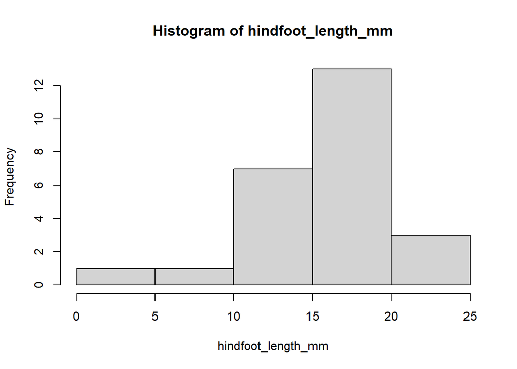

```r
# Simulate hindfoot lengths for the survey data
set.seed(1) # Setting the seed makes the random sample come out the same each time
# Randomly sample from a normal distribution with mean of 15 and SD of 5
# The number of elements should be the same as the number of surveys
hindfoot_length_mm <- rnorm(n = nrow(surveys), mean = 15, sd = 5)
hist(hindfoot_length_mm)
```

```r
# Add this column to the survey data
surveys <- surveys %>%
  mutate(hindfoot_mm = hindfoot_length_mm)

# Add in a new season of data from the surveys_2023 data set
surveys_2023 <- read_csv("data/surveys_2023.csv")
surveys_augmented <- bind_rows(surveys, surveys_2023)

# Summarize to make sure binding worked
## Check that number of rows is as expected
nrow(surveys_augmented) == (nrow(surveys) + nrow(surveys_2023))
```

```
## [1] TRUE
```

```r
## Check whether NAs were introduced by counting the number of NAs in each column
NA_counts <- surveys_augmented %>%
  summarize(across(everything(), ~sum(is.na(.))))
pivot_longer(NA_counts, everything())
```

```
## # A tibble: 12 × 2
##    name           value
##    <chr>          <int>
##  1 sample_id          0
##  2 species            0
##  3 sex                0
##  4 weight             2
##  5 habitat_class1     0
##  6 habitat_class2     0
##  7 habitat_class3     0
##  8 year               0
##  9 date              25
## 10 time               0
## 11 hindfoot_mm       25
## 12 sampling_date     25
```

```r
# Make sure names match and redo binding
names(surveys)
```

```
##  [1] "sample_id"      "species"        "sex"            "weight"
##  [5] "habitat_class1" "habitat_class2" "habitat_class3" "year"
##  [9] "date"           "time"           "hindfoot_mm"
```

```r
names(surveys_2023)
```

```
##  [1] "sample_id"      "species"        "sex"            "weight"
##  [5] "habitat_class1" "habitat_class2" "habitat_class3" "year"
##  [9] "sampling_date"  "time"
```

```r
surveys_2023 <- rename(surveys_2023, date=sampling_date)
surveys_augmented <- bind_rows(surveys, surveys_2023)
```

## Section 3: Joining datasets

```r
# Read in the species info file
species_info <- read_csv(here("scripts/data/species_info.csv"))
# Join the two datasets using species as the key
surveys_joined <- surveys %>%
  left_join(species_info, by = "species")
# Check to see if this worked
unique(surveys_joined$common_name)
```

```
## [1] "Gray Mouse"  "Field Vole"  "River Rat"   "Swamp Shrew"
```

```r
# Join the summarized datasets with species info
avg_by_species <- avg_by_species %>%
  left_join(species_info)
# Use an inner join
surveys_inner <- surveys %>%
  inner_join(species_info, by = "species")
# Compare row counts between the left and inner joins
(nrow(surveys_joined) == nrow(surveys_inner))
```

```
## [1] TRUE
```

```r
# Semi join: keep only surveys for native species
native_surveys <- surveys %>%
  semi_join(species_info %>% filter(status=="native"), by = "species")
nrow(native_surveys)
```

```
## [1] 21
```

```r
nrow(surveys)
```

```
## [1] 25
```

```r
# Anti join: find species never observed in surveys
unobserved_species <- species_info %>%
  anti_join(surveys_inner, by = "species")
```

Under what circumstance(s) do you expect an inner join and a left join of the same two datasets to produce data frames with different numbers of rows?

*inner and left join will produce different data frames when there are values that are in the left df that are not in the right*

## Section 4: Wide and long form

```r
# Summarize number of samples per species per habitat type 1
species_habs <- surveys %>%
  group_by(species, habitat_class1) %>%
  summarize(n = n())
# Create a table with species as rows and habitat type as columns
# Where any missing species-habitat combinations are filled with zero
species_habs_wide <- pivot_wider(species_habs,
                            names_from = species, habitat_class1,
                            values_from = n,
                            values_fill = 0)
species_habs_wide
```

```
## # A tibble: 3 × 5
##   habitat_class1   sp1   sp2   sp3   sp4
##   <chr>          <int> <int> <int> <int>
## 1 forest             4     0     1     2
## 2 grassland          2     5     1     1
## 3 wetland            3     2     2     2
```

```r
# Pivot back to long format

species_habs_long <- pivot_longer(species_habs_wide,
                                  cols = -habitat_class1,
                                  names_to = "species",
                                  values_to = "count")
head(species_habs_long)
```

```
## # A tibble: 6 × 3
##   habitat_class1 species count
##   <chr>          <chr>   <int>
## 1 forest         sp1         4
## 2 forest         sp2         0
## 3 forest         sp3         1
## 4 forest         sp4         2
## 5 grassland      sp1         2
## 6 grassland      sp2         5
```

```r
# Create table where each row is a year and
# columns are counts per the combination of habitat types 1 and habitat type 2
# Fill any missing species-habitat combinations with zero !!!STILL NEED TO VISIT!!!

year_plot_counts <- surveys %>%
  group_by(year, habitat_class1, habitat_class2) %>%
  summarize(count = n(), .groups = "drop") %>%
  mutate(habitat_combo = str_c(habitat_class1, habitat_class2, sep = "_")) %>%
  select(year, habitat_combo, count) %>%
  pivot_wider(
    names_from = habitat_combo,
    values_from = count,
    values_fill = list(count = 0)
  )
year_plot_counts
```

```
## # A tibble: 3 × 5
##    year forest_forested grassland_open wetland_forested wetland_open
##   <dbl>           <int>          <int>            <int>        <int>
## 1  2020               2              4                1            2
## 2  2021               2              2                0            1
## 3  2022               3              3                2            3
```

```r
# Reshape avg_weight and sd_weight to long format
species_stats_long <- avg_by_species %>%
  pivot_longer(cols = c(avg_weight, sd_weight),
               names_to = "statistic",
               values_to = "value")

# Reformat the "statistic" column so that values are "mean" and "sd"
# Hint: you could do this with stringr or if_else
species_stats_long <- species_stats_long %>%
  mutate(statistic = if_else(statistic == "avg_weight", "mean", statistic))
species_stats_long <- species_stats_long%>%
         mutate(statistic = if_else(statistic == "sd_weight", "sd", statistic))


head(species_stats_long)
```

```
## # A tibble: 6 × 5
##   species common_name status     statistic value
##   <chr>   <chr>       <chr>      <chr>     <dbl>
## 1 sp1     Gray Mouse  native     mean      118
## 2 sp1     Gray Mouse  native     sd         31.4
## 3 sp2     Field Vole  native     mean      114.
## 4 sp2     Field Vole  native     sd         24.6
## 5 sp3     River Rat   introduced mean      145
## 6 sp3     River Rat   introduced sd         37.9
```

## Section 5: Open-ended practice

Here, we’ll practice with some published data: https://doi.org/10.5066/P97NEY5Y.

This repository includes three datasets detailing the movement and avian influenza infection status of waterfowl in California:

- individual_data_attributes.csv: Individual-level data (ID, species, infection status) for tagged birds
- local_movement_data.csv: Data from GPS telemetry of these same birds soon after tagging and sampling
- spring_migration_data.csv: Data derived from GPS telemetry of these same birds, used to derive the timing of their spring migrations. We will not use this dataset in this exercise.

The repository also includes a file called DataRelease.xml, which is the Readme file for the repository. It describes the data and defines column headings. You can open this file in a browser or text editor (Notepad, TextEdit, etc.), but it is in a format that is difficult to read without installing a new program.

Download individual_data_attributes.csv and local_movement_data.csv and place them in your raw data folder. You can open them in Excel to explore the data structure and column names.

First, explore the data a little and do any necessary cleaning:

```r
# Read in the individual-level data
bird_data <- read_csv(here("scripts/data/individual_data_attributes.csv"))
# Read in the movement data
move_data <- read_csv(here("scripts/data/local_movement_data.csv"))
# Check the column formats and correct as needed (hint: check time columns)
str(bird_data)
```

```
## spc_tbl_ [165 × 7] (S3: spec_tbl_df/tbl_df/tbl/data.frame)
##  $ ID                : chr [1:165] "17064_61152" "17066_61271" "17068_61165" "17069_61131" ...
##  $ models            : chr [1:165] "space use" "migration_pcr, migration_ab, space use" "space use" "space use" ...
##  $ species           : chr [1:165] "Aythya valisineria" "Aythya valisineria" "Aythya valisineria" "Aythya valisineria" ...
##  $ sampling_date     : chr [1:165] "12/2/17" "12/10/17" "12/3/17" "12/2/17" ...
##  $ active_infection  : logi [1:165] FALSE FALSE FALSE FALSE FALSE FALSE ...
##  $ antibody_detection: logi [1:165] TRUE TRUE FALSE FALSE TRUE TRUE ...
##  $ sex               : chr [1:165] "F" "M" "F" "F" ...
##  - attr(*, "spec")=
##   .. cols(
##   ..   ID = col_character(),
##   ..   models = col_character(),
##   ..   species = col_character(),
##   ..   sampling_date = col_character(),
##   ..   active_infection = col_logical(),
##   ..   antibody_detection = col_logical(),
##   ..   sex = col_character()
##   .. )
##  - attr(*, "problems")=<externalptr>
```

```r
str(move_data)
```

```
## spc_tbl_ [35,162 × 4] (S3: spec_tbl_df/tbl_df/tbl/data.frame)
##  $ ID       : chr [1:35162] "17064_61152" "17064_61152" "17064_61152" "17064_61152" ...
##  $ longitude: num [1:35162] -122 -122 -122 -122 -122 ...
##  $ latitude : num [1:35162] 38.2 38.2 38.2 38.2 38.2 ...
##  $ timestamp: chr [1:35162] "12/3/2017 15:42" "12/3/2017 16:18" "12/3/2017 16:54" "12/3/2017 17:30" ...
##  - attr(*, "spec")=
##   .. cols(
##   ..   ID = col_character(),
##   ..   longitude = col_double(),
##   ..   latitude = col_double(),
##   ..   timestamp = col_character()
##   .. )
##  - attr(*, "problems")=<externalptr>
```

```r
bird_data <- bird_data %>%
  mutate(sampling_date = mdy(sampling_date))
move_data <- move_data %>%
  mutate(timestamp = mdy_hm(timestamp))

# Add any other exploration you would like here...

unique(move_data$ID)
```

```
##   [1] "17064_61152"  "17066_61271"  "17068_61165"  "17069_61131"  "17070_61201"
##   [6] "17071_61168"  "17072_61228"  "171252_61274" "171253_61203" "171254_61269"
##  [11] "171256_61265" "171257_61230" "171258_61194" "171259_61112" "171260_61115"
##  [16] "171261_61193" "171262_61126" "171263_61234" "171264_61270" "171265_61122"
##  [21] "171266_61176" "171267_61162" "171269_61161" "171271_61277" "180625.1"
##  [26] "180627.2"     "180628.1"     "180631.1"     "180632.1"     "180634.1"
##  [31] "180635.1"     "180636.1"     "180637.1"     "180638.1"     "180640.1"
##  [36] "180642.1"     "180649.3"     "180661.2"     "180662.1"     "180663.1"
##  [41] "180667.2"     "180668.1"     "180669.1"     "180670.1"     "180671.1"
##  [46] "180673.1"     "180674.1"     "180675.1"     "180677.1"     "180680.1"
##  [51] "180681.1"     "182131.1"     "182132.1"     "182136.1"     "182137.1"
##  [56] "182138.1"     "182139.1"     "182140.1"     "182141.1"     "182142.1"
##  [61] "182143.1"     "182144.1"     "182146.1"     "182146.2"     "182147.1"
##  [66] "182147.2"     "182147.3"     "182148.1"     "182148.2"     "182281_61416"
##  [71] "182282_61387" "182284_61403" "182285_61441" "182288_41467" "182289_61442"
##  [76] "182295_61456" "182296_61391" "182298_61417" "182300_61400" "182301_61390"
##  [81] "182302_61438" "182303_61425" "182306_61392" "182307_61365" "182308_61427"
##  [86] "182309_61434" "182310_61451" "182311_61367" "182312_61389" "182314_61293"
##  [91] "182315_61423" "182317_61426" "182318_61395" "182319_61457" "191540.1"
##  [96] "191545.1"     "BIRD 74.2"    "BIRD 77.1"    "BIRD 82.1"    "BIRD 83.1"
## [101] "BIRD 86.1"    "BIRD 87.1"    "BIRD 88.1"    "BIRD 89.1"    "BIRD 90.1"
## [106] "BIRD 93.1"    "DRIB 24.1"    "DRIB 71.1"    "REPL 14.2"    "SAKR 05.1"
## [111] "SAKR 09.1"    "SAKR 18.1"    "SIMP 08.1"    "SIMP 38.1"    "SIMP 40.1"
## [116] "TEAL 51.3"    "TEAL 79.1"    "WATE 15.1"    "WATE 34.1"    "WATE 46.1"
## [121] "WATE 47.1"    "WATE 48.1"    "WATE 49.1"    "WATE 50.1"    "WATE 51.1"
## [126] "WATE 52.1"    "WATE 53.1"    "WATE 54.1"    "WATE 55.1"    "WATE 56.1"
## [131] "WATE 57.1"    "WATE 58.1"    "WATE 59.1"    "WATE 60.1"    "WATE 61.1"
## [136] "WATE 62.1"    "WATE 65.1"    "WATE 66.1"    "WATE 67.1"    "WATE 68.1"
```

### Summarizing:

Create a table with the number of GPS locations per individual (Make sure to create a new object that saves this information)

```r
move_data <- move_data %>%
  mutate(long_lat= str_c(longitude, latitude, sep=", "))


GPS_per_ind <- move_data %>%
  group_by(ID) %>%
  summarize(number_of_GPS_locations=n())


# What is the range of number of locations per bird?

range(GPS_per_ind$number_of_GPS_locations)
```

```
## [1]  39 576
```

```r
# 39-576
```

Calculate the duration of tracking for each bird in days, while also including the number of GPS locations per bird (as above). Make sure to create a new object that saves this information.

```r
GPS_per_ind_and_duration <- move_data %>%
  group_by(ID) %>%
  summarize(number_of_GPS_locations=n(),
    start_time=min(timestamp),
    end_time=max(timestamp),
    duration=difftime(end_time, start_time, units="hours"))




# What is the range of tracking duration?
range(GPS_per_ind_and_duration$duration)
```

```
## Time differences in hours
## [1]  67.51667 288.00000
```

```r
#67.51667-288.0 hours
```

Make a contingency table of active infection and antibody detection, i.e., how many individuals are in each combination of categories? This should use the individual data (not movement data). Please include missing values in your summary. You can do this in a few ways, but you should end up with a table that looks something like this (though maybe in a different order or with different column names):

| active_infection | antibody_detection | Freq |
| --- | --- | --- |
| FALSE | FALSE | 21 |
| FALSE | TRUE | 42 |
| FALSE | NA | 77 |
| TRUE | FALSE | 1 |
| TRUE | TRUE | 2 |
| TRUE | NA | 8 |
| NA | FALSE | 6 |
| NA | TRUE | 8 |

```r
contigency_table <- bird_data %>%
  count(active_infection, antibody_detection)
```

### Joining and summarizing:

Add active infection status, species, and sex to the movement data.

```r
move_data_joined <- move_data %>%
  left_join(bird_data %>% select(ID, active_infection, antibody_detection, species, sex))
```

What is (1) the number of locations and (2) the range of tracking duration by species? You can do this in a few ways, you should end up with a table that looks like this (hint: you might want to start with the tracking duration object you created above):

| species | min_duration | max_duration | n_locs |
| --- | --- | --- | --- |
| Anas acuta | 2.813194 days | 12.00000 days | 64 |
| Anas platyrhynchos | 2.896528 days | 12.00000 days | 28 |
| Aythya valisineria | 8.750000 days | 11.98819 days | 50 |

```r
 GPS_per_ind_and_duration <- GPS_per_ind_and_duration %>%
left_join(bird_data %>% select(ID, active_infection, antibody_detection, species, sex))
trackrng_and_numofloc <-GPS_per_ind_and_duration %>%
  group_by(species) %>%
  summarize(min_duration= min(duration),
           max_duration= max(duration),
           n_locs= sum(number_of_GPS_locations))
```

Did you get a warning message? What does it mean? Does it indicate a problem?

*the only warning message I got was “Error in `summarize()`: ℹ In argument: `n_locs = count(number_of_GPS_locations)`. ℹ In group 1: `species = "Anas acuta"`.” Count was not able to be used on this so I changed it to sum*

The code chunk below walks you through the calculation of movement rates, which we will use in the next chunk.

```r
# Add a movement rate column to the movement data (i.e., distance traveled per hour)
# For now, we will just use latitude and longitude as your location data (don't worry
# about the fact that you're caclulating distances in decimal degrees).
move_data <- move_data %>%
  group_by(ID) %>%
  mutate(lag_longitude = lag(longitude), lag_latitude = lag(latitude)) %>%
  mutate(distance = sqrt((longitude - lag_longitude)^2 + (latitude - lag_latitude)^2))

# Add a time difference column
move_data <- move_data %>%
  mutate(dt = difftime(timestamp, lag(timestamp), units = "hours"))

# Calculate movement rate
move_data <- move_data %>%
  mutate(move_rate = distance/as.numeric(dt))
```

In the code chunk above, I grouped `move_data` by `ID` before calculating lagged longitude and latitude. What does this achieve?

*This made it so R would manipulate the data frame based on the ID columns and make it so R calculates the movement rate for each individual*

Calculate the mean and standard error (note! not standard deviation) in movement rates by species and sex, ordered by species.

The standard error of a sample is the standard deviation divided by the square root of the sample size (check out the knitted HTML for the rendered version of the equation below:

$SE = \frac{\sigma}{\sqrt{n}}$

```r
move_data <- move_data %>%
left_join(bird_data %>% select(ID, sex,species))
summary_stats <- move_data %>%
  group_by(species, sex) %>%
  summarise(
    mean_movement = mean(move_rate, na.rm = TRUE),
    se_movement = sd(move_rate, na.rm = TRUE) / sqrt(n()))
```

For which species do you see sex differences in movement rates?

*Anas platyrhynchos is the species that had the largest difference in movement rate between male and female. All three of them had at least some difference between the sexes.*

### Wide and long form:

Create a table that shows the number of birds sampled in each year for each species. You will use the individual-level data for this.

Your table should look like this:

| species | `2015` | `2016` | `2017` | `2018` | `2019` |
| --- | --- | --- | --- | --- | --- |
| Anas acuta | 18 | 10 | 0 | 28 | 14 |
| Anas platyrhynchos | 5 | 0 | 4 | 7 | 12 |
| Aythya valisineria | 0 | 0 | 25 | 26 | 6 |
| Anser albifrons | 0 | 0 | 0 | 12 | 0 |

```r
 species_year_wide <- move_data_joined %>%
  mutate(year=year(timestamp)) %>%
  group_by(species,year) %>%
  summarize(num_birds=n_distinct(ID)) %>%
   pivot_wider(names_from = year,
    values_from = num_birds,
    values_fill = 0)
```